# RProject

Chi

5/3/2020

## Loading Packages

```r
library(dplyr)
library(ggplot2)
```

## Loading Data Set

###Part 1: Data

####Part 1.1: How the observations in the sample are collected. Information extracted from bfrss user guide as follow: (https://www.cdc.gov/brfss/data_documentation/pdf/UserguideJune2013.pdf) The BRFSS uses two samples: one for landline telephone respondents and one for cellular telephone respondents. Since landline telephones are often shared among persons living within a residence, household sampling is used in the landline sample. Household sampling requires interviewers to collect information on the number of adults living within a residence and then select randomly from all eligible adults. Cellular telephone respondents are weighted as single adult households. Landline sample applies Disproportionate stratified sampling (DSS) Cellular telephone respondents are randomly selected with each having equal probability of selection.

####Part 1.2 Generalization and Causality: Generalization can be applied for all states participating since the random sampling is used, however, causation could not be deducted as there is no random assignment.

###Part 2: Research Questions

Research Question 1: Interested Variables: Health (genhlth) and Income Level (income2), Gender (sex) Investigating the relation between thee income level and health, and is there any differences recognized in different gender?

Research Question 2: Interested Variables:Health (genhlth) and Education Level(educa), Gender (sex) Is there any differences between education level and health status in terms of gender?

Research Question 3: Do sex and sleep time have relationship with general health?

###Part 3: Exploratory data analysis

**Research Question 1:**

```r
#Select interested variables and group them into a data set
dataset1<-select(brfss2013,genhlth, income2, sex)
#Remove all NA's
dataset1<-dataset1%>%filter(genhlth!="NA", income2!="NA", sex!="NA")
#Using "group_by" function for Health Status
total_ob<-nrow(brfss2013)
dataset1%>%group_by(genhlth)%>%summarise(count=n(),percentage=n()*100/total_ob)
```

```
## # A tibble: 5 x 3
##   genhlth    count percentage
##   <fct>      <int>      <dbl>
## 1 Excellent  74253      15.1
## 2 Very good 138247      28.1
## 3 Good      127701      26.0
## 4 Fair       55602      11.3
## 5 Poor       23116       4.70
```

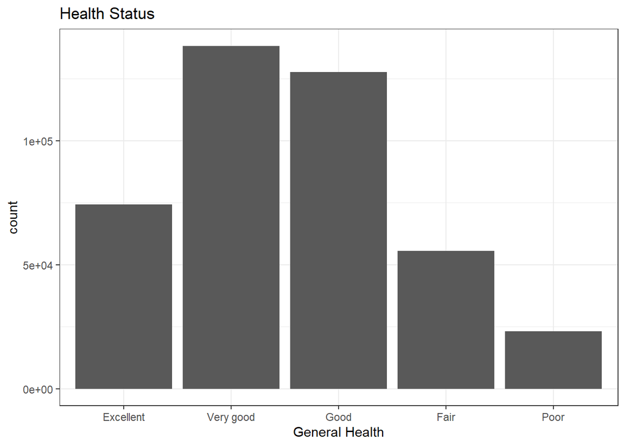

```r
#Draw Bar Graph for Health Status
ggplot(dataset1, aes(x=genhlth))+geom_bar()+ggtitle('Health Status')+xlab('General Health')+theme_bw()
```

```r
#Calculate the percentage of Income Level using group_by
dataset1%>%group_by(income2)%>%summarise(count=n(),percentage=n()*100/total_ob)
```

```
## # A tibble: 8 x 3
##   income2            count percentage
##   <fct>              <int>      <dbl>
## 1 Less than $10,000  25252       5.13
## 2 Less than $15,000  26632       5.42
## 3 Less than $20,000  34705       7.06
## 4 Less than $25,000  41563       8.45
## 5 Less than $35,000  48687       9.90
## 6 Less than $50,000  61319      12.5
## 7 Less than $75,000  65102      13.2
## 8 $75,000 or more   115659      23.5
```

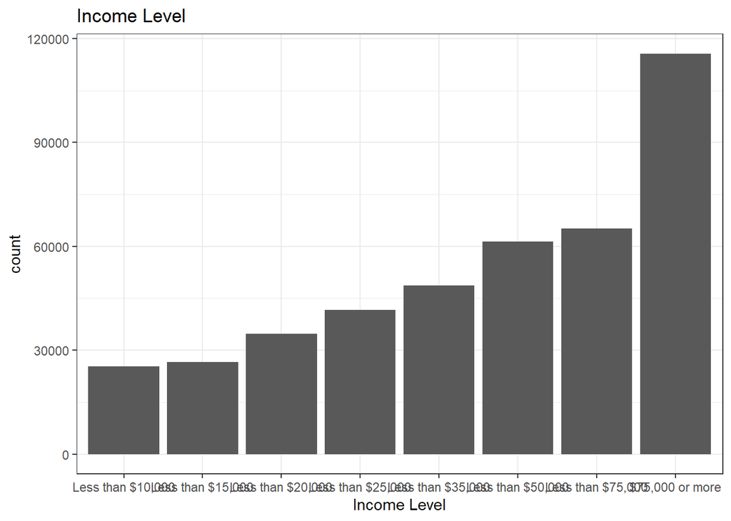

```r
#Draw Bar Graph for Income Level
ggplot(dataset1, aes(x=income2))+geom_bar()+ggtitle('Income Level')+xlab('Income Level')+theme_bw()
```

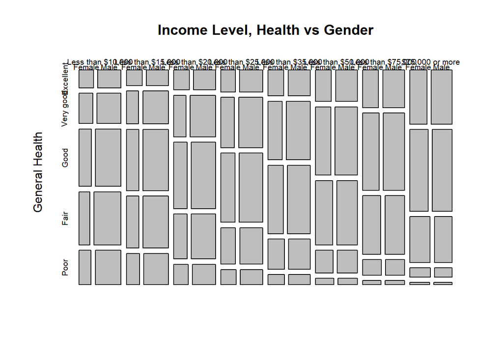

```r
#Create factor for gender
levels(dataset1$sex)<-c("Female", "Male")

#Create a contigency table
cont_table<- table(dataset1$income2,dataset1$genhlth, dataset1$sex)

#Draw Mosaic Plot for three variables
mosaicplot(prop.table(cont_table,1), main='Income Level, Health vs Gender', xlab='',ylab='General Health')
```

#Conclusion (1) The higher the income level is, the better the health status that person possesses. (2) There is no big difference between female and male affecting to other two variables. Thus, gender has nothing to do with the relation between income level and health.

**Research Question 2:**

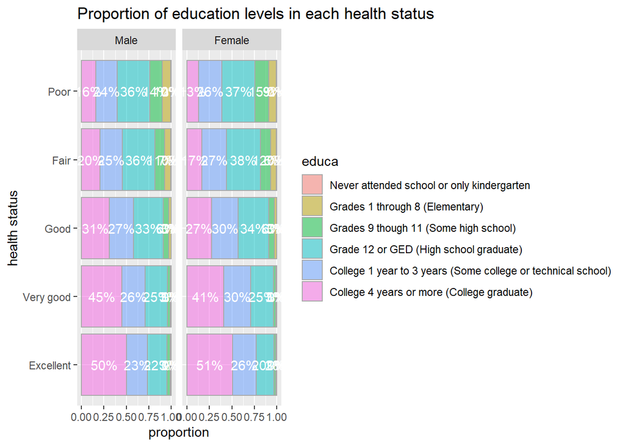

```r
dataset1<-select(brfss2013,genhlth, income2, sex, educa)

dataset1<-dataset1 %>%filter(!is.na(dataset1$genhlth), !is.na(dataset1$sex), !is.na(dataset1$educa)) %>%group_by(genhlth, sex, educa) %>%summarize(n = n()) %>%mutate(percentage_genhlth = n/sum(n), posn_pct = cumsum(percentage_genhlth)-0.5*percentage_genhlth)
library(RColorBrewer)
library(knitr)
ggplot(dataset1, aes(x = genhlth, y = percentage_genhlth, fill = educa)) + geom_bar(stat = "identity", alpha = 0.5, col = "dark grey") +facet_wrap(~sex, ncol = 2) +geom_text(aes(label = paste0(sprintf("%.0f", percentage_genhlth*100),"%"), y=1-posn_pct), col = "white") +labs(title = "Proportion of education levels in each health status") +scale_x_discrete("health status") +scale_y_continuous("proportion") +coord_flip() +scale_y_continuous("proportion") +coord_flip()
```

#Conclusion There is not much differences recognized in terms of gender. As regards people who attended college 4 years or more, male is considered to have slightly better health status except for the last category “Excellent”

**Research Question 3:**

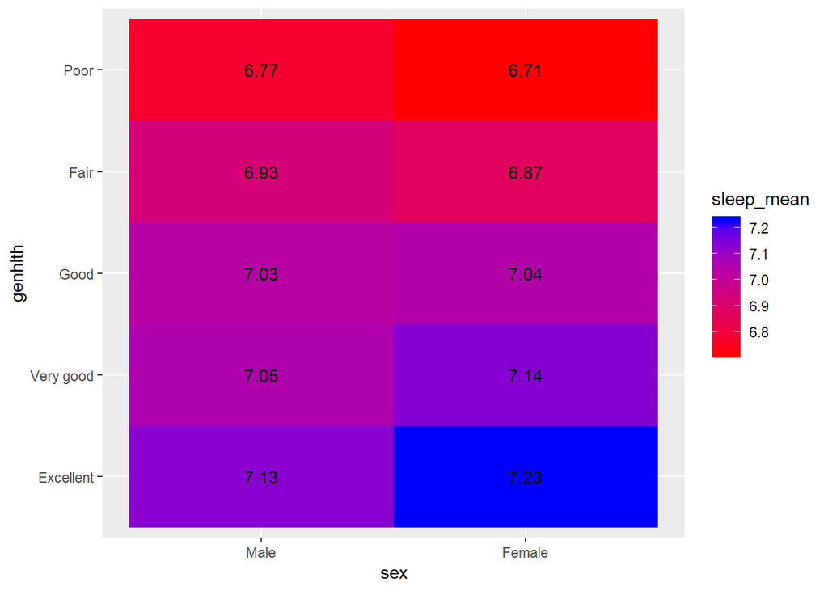

```r
dataset2 <- brfss2013 %>%filter(!is.na(sleptim1),!is.na(genhlth),!is.na(sex)) %>% mutate(sleptim1_scaled = as.numeric(scale(sleptim1))) %>% select(sex, sleptim1, genhlth,sleptim1_scaled)

dataset3 <- dataset2 %>%group_by(genhlth, sex) %>%summarise(n=n(), sleep_mean = mean(sleptim1), sleep_scaled = mean(sleptim1_scaled))

ggplot(data= dataset3, aes(sex, genhlth)) + geom_tile(aes(fill = sleep_mean)) + scale_fill_gradient(low= "red", high= "blue") + geom_text(aes(label = round(sleep_mean,2)))
```